# Clase prácticas. Día6.

Juan A. Ferrer-Bonsoms

# 1 Teorema central del límite

## 1.1 Demostracion empirica con suma de uniformes

Vamos a visualizar el teorema central del límite partiendo de datos aleatorios procedentes de una distribución Uniforme `U(0,1)`.

Para ello vamos a seguir los siguientes pasos:

1.- vamos a determinar los parámetros de la distribución uniforme y el número de uniformes que vamos a sumar. Vamos a llamar “a” al valor mínimo y “b” al valor máximo. “nn” hace referencia al número de “uniformes” que vamos a sumar. En este caso, vamos a empezar sumando solo una uniforme.

```r
a <- 0 #valor minimo de la uniforme
b <- 1 #valor maximo de la uniforme
nn <- 1 #numero de uniformes que vamos a sumar
```

2.- El siguiente paso es generar valores aleatorios que proceden de sumar una uniforme. Para ello vamos a crear una matriz con datos que proceden de una uniforme `U(0,1)`. Para ellos vamos a utilizar la función `runif`. Para poder visualizar la distribución de esta variable es necesario generar muchos datos aleatorios. Para poder visualizar bien vamos a generar 10.000 valores aleatorios.

```r
u1 <- matrix(data = runif(10000,min=a,max=b),
             nrow = nn,ncol=10000)
u1 <- colSums(u1)
```

Finalmente tenemos un vector `u1` que contiene 10.000 valores aleatorios e independientes. Cada uno de estos valores procede una distribución `U(0,1)`.

3.- El siguiente paso es dibujar como se distribuyen estos datos. Para ello vamos a hacer un histograma:

```r
hist(u1,breaks = 100,freq = F,
     main=expression(sum(U[i](0,1), i==1, 1)),
     ylim = c(0,1.5))
```

4.- Por último, vamos a aproximar la distribución `U(0,1)` con una distribución Normal. La distribución normal a la que se podría aproximar esta distribución sería:

$$\mu = \sum_i^{nn}E(U(a,b))= nn·E(U(a,b)) = nn·\frac{a+b}{2}= 1·\frac{0+1}{2} = 0.5 \\
\sigma^2 = \sum_i^{nn}VAR(U(a,b))= nn·VAR(U(a,b)) = nn·\frac{(b-a)^2}{12}= 1·\frac{(1-0)^2}{12} = 1/12$$

Vamos a crear dos variables en R (media, varianza) para representar estos dos valores:

```r
media <- nn*(a+b)/2 #media esperada
varianza <- nn*(b-a)^2/12 #varianza esperada
```

5.- El úlitmo paso es añadir en la gráfica anterior el la función de densidad teórica de la distribución normal a la que estamos aproximando `u1`:

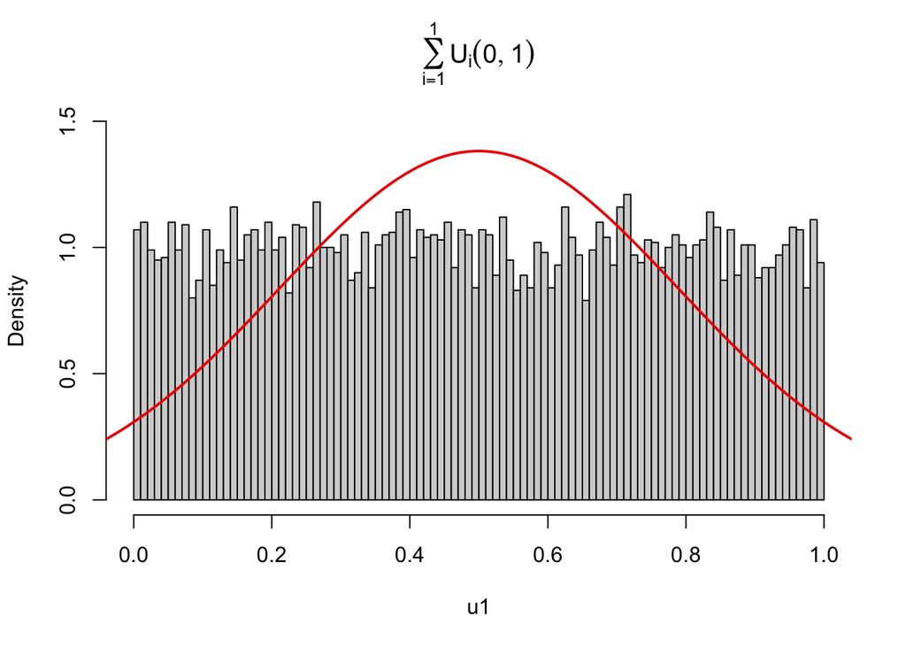

```r
x <- seq(from = media-3*sqrt(varianza),
         to = media + 3*sqrt(varianza),
         by = 0.01)
y <- dnorm(x,mean = media,sd=sqrt(varianza))
lines(x,y,type="l",lwd=2,col="red2")
```

Como se puede observar, esta aproximación no es muy buena. Para poder aplicar el TCL tenemos que tener la suma de un número considerable de valores.

El siguiente código vamos a graficar para la suma de 2 uniformes, de 5 uniformes y de 10 uniformes:

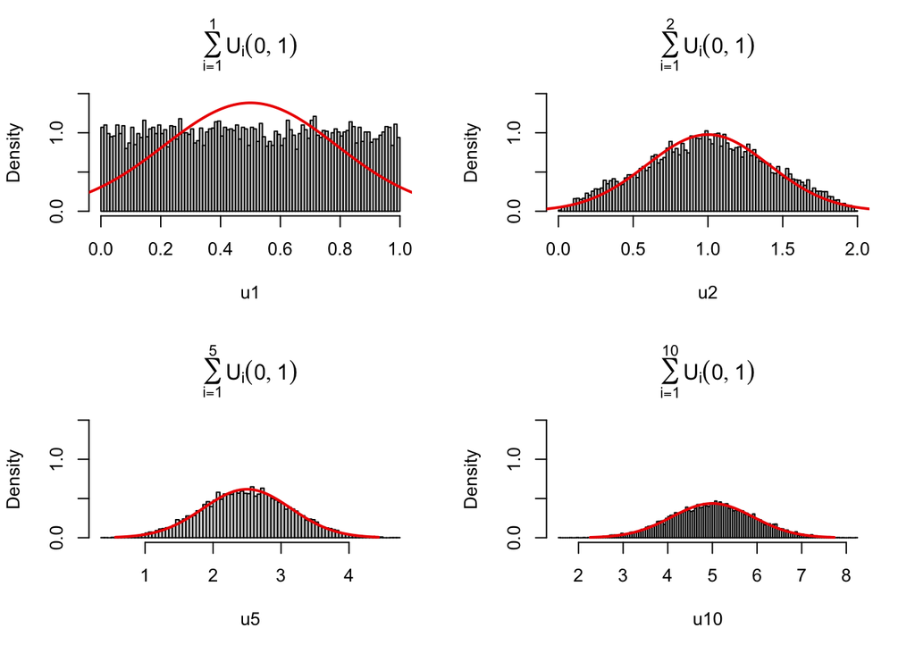

```r
par(mfrow=c(2,2)) #esta función sirve para crear varias
#graficas en un mismo plot
hist(u1,breaks = 100,freq = F,
     main=expression(sum(U[i](0,1), i==1, 1)),
     ylim = c(0,1.5))
lines(x,y,type="l",lwd=2,col="red2")


# 2 uniformes
nn <- 2 #numero de uniformes que vamos a sumar
u2 <- matrix(data = runif(10000*nn,min=a,max=b),
             nrow = nn,ncol=10000)
u2 <- colSums(u2)
media2 <- nn*(a+b)/2 #media esperada
varianza2 <- nn*(b-a)^2/12 #varianza esperada


hist(u2,breaks = 100,freq = F,
     main=expression(sum(U[i](0,1), i==1, 2)),
     ylim = c(0,1.5))
x2 <- seq(from = media2-3*sqrt(varianza2),
         to = media2 + 3*sqrt(varianza2),
         by = 0.01)
y2 <- dnorm(x2,mean = media2,sd=sqrt(varianza2))
lines(x2,y2,type="l",lwd=2,col="red2")




# 5 uniformes
nn <- 5 #numero de uniformes que vamos a sumar
u5 <- matrix(data = runif(10000*nn,min=a,max=b),
             nrow = nn,ncol=10000)
u5 <- colSums(u5)
hist(u5,breaks = 100,freq = F,
     main=expression(sum(U[i](0,1), i==1, 5)),
     ylim = c(0,1.5))
media5 <- nn*(a+b)/2 #media esperada
varianza5 <- nn*(b-a)^2/12 #varianza esperada
x5 <- seq(from = media5-3*sqrt(varianza5),
         to = media5 + 3*sqrt(varianza5),
         by = 0.01)
y5 <- dnorm(x5,mean = media5,sd=sqrt(varianza5))
lines(x5,y5,type="l",lwd=2,col="red2")



# 10 uniformes
nn <- 10 #numero de uniformes que vamos a sumar
u10 <- matrix(data = runif(10000*nn,min=a,max=b),
             nrow = nn,ncol=10000)
u10 <- colSums(u10)
hist(u10,breaks = 100,freq = F,
     main=expression(sum(U[i](0,1), i==1, 10)),
     ylim = c(0,1.5))
media10 <- nn*(a+b)/2 #media esperada
varianza10 <- nn*(b-a)^2/12 #varianza esperada
x10 <- seq(from = media10-3*sqrt(varianza10),
         to = media10 + 3*sqrt(varianza10),
         by = 0.01)
y10 <- dnorm(x10,mean = media10,sd=sqrt(varianza10))
lines(x10,y10,type="l",lwd=2,col="red2")
```

## 1.2 Aproximación de una Binomial y una Poisson a una Normal

En los apuntes del tema 4 se ve que la función de masa de una variable Binomial B(n,p) conforme crece “n” va adquiriendo la forma de una distribución normal. De esta manera, el cálculo de probabilidades utilizando la variable Binomial se puede aproximar utilizando la normal correspondiente:

$$P(a \leq B(n,p) \leq b) \cong P(a-0.5 \leq N(np,\sqrt{npq})\leq b+0.5)$$

Para que esta aproximación se buena, tenemos que tener un valor de “n” suficientemente grande. Por convenio, se decide utilizar la aproximación np > 5.

Para la variable Poisson, se vio que por convenio para una valor de $\lambda > 15$ , los cálculos de probabilidades de la Poisson se puede aproximar mediante una distribución normal de la siguiente manera:

$$P(a \leq Poisson(\lambda) \leq b) \cong P(a-0.5 \leq N(\lambda,\sqrt{lambda})\leq b+0.5)$$

### 1.2.1 Ejercicios

1.- Se pide:

1. (extra) Dibujar en la misma gráfica la función de masa de una distribución Binomial `B(n=100,p=0.3)` y la función de densidad de su aproximación a una distribución Normal.
2. Calcular, de forma exacta, la probabilidad de que una B(n=100,p=0.3) se mayor o igual a 25 y menor o igual a 30. (**Sol. 0.4355534**)
3. Calcular la misma probabilidad utilizando la aproximación normal.(**Sol. 0.4284108**)
4. (extra) Calcular la misma probabilidad, utilizando la aproximación normal sin la corrección del 0.5. (**Sol. 0.3623832**)
5. Calcular, de forma exacta, la probabilidad de que una Binomial B(n=100,p=0.3) sea mayor a 28 y menor a 33. (**Sol. 0.3339404**)
6. Calcular la misma probabilidad con la aproximación normal.(**Sol.0.3356002**)

2.- Se pide:

1. (extra) Dibujar, en la misma gráfica, la función de masa de una distribución de Poisson de media 20 y la función de densidad de su aproximación normal.
2. Calcular, de forma exacta, la probabilidad de que una Poisson de media 20 tenga un valor mayor o igual a 23 y menor o igual a 26. (**Sol. 0.2015019**)
3. Calcular la misma probabilidad con la aproximación normal. (**Sol. 0.2150248**)

# 2 Suma de variables $\gamma$

Otro de los teoremas que se ha visto en clase es:
$$\sum_i \gamma(a,p_i)= \gamma(a,\sum_ip_i)$$

**Extra** Vamos a comprobar que esta propiedad se cumple. Para ello se propone como ejercicio (parecido al ejercicio 7 del apartado de la exponencial de la práctica del día 5):

1.- Crear una matriz A, que contenga 10 filas y 10.000 columnas con valores aleatorios procedentes de una exponencial de media 2.

2.- Sumar por columnas los elementos de la matriz A (utilizar la función `colSums()`). El resultado debe ser un vector “sumcolumnas” de 10.000 elementos. Cada elemento de este vector es el resultado de sumar 10 exponenciales de media 2.

3.- Crear una gráfica que muestre la función de densidad empírica del vector “sumcolumnas”. En la misma gráfica, dibujar la función de densidad teórica correspondiente. En este caso, como tenemos la suma de 10 exponenciales, es decir, tenemos: (recuerdo que $Exp(a) = \gamma(a,p=1)$)

$$\sum_i^{10} \gamma(a=0.5,p=1)= \gamma(a=0.5,p=10)$$

# 3 Ejercicios

1.- Se desea realizar una encuesta para detectar si un producto A es preferido sobre otro producto B. En la encuesta participaron 1000 personas. Se considera que la probabilidad de que una persona prefiera el producto A es de 0.5. Se pide:

1. Calcular, de forma exacta, la probabilidad de que 550 personas o más prefieran el producto A sobre el B. (**Sol. 0.000865268**)
2. Calcular con la aproximación normal la misma probabilidad.(**Sol. 0.000872085**)

2.- Un supermercado de pueblo estiman que las personas que pasan por caja a la hora se comporta según una distribución de Poisson de media 10. Se define X como el número de personas que pasan por caja en una semana (56 horas).

1. Dibujar la función de masa de X. En la misma gráfica, dibujar la función de densidad de su aproximación normal en rojo.
2. Calcular, de forma exacta, la probabilidad de que 600 personas o más pasen por caja en una semana.(**Sol. 0.04875205**)
3. Calcular la misma probabilidad con la estimación normal. (**Sol. 0.04754089**)
4. Si en lo que va de semana ya han pasado por caja 550 personas. ¿Cuál es la probabilidad de que al final de la semana hayan pasado por caja 600 personas o menos?(calcular la probabilidad de forma exacta) (**Sol. 0.9331872**)

3.- En un concurso de disparo a la diana, cada concursante tiene 10 disparos. Se considera que un concursante tiene una probabilidad de acertar de 0.8 y que cada disparo es independiente de otro. Además, cada concursante puede tener hasta 5 disparos extra. Para saber cuantos disparos extra tiene, hay una urna con 5 bolas blancas y 10 bolas negras. El concursante tiene que extraer de la urna 10 bolas. El número de bolas blancas extraídas de la urna define el número de disparos extra.

1. ¿Cuál es la probabilidad de que un concursante tenga 5 disparos extra? (**Sol. 0.08391608**)
2. ¿Cuál es la probabilidad de que un concursante acierte 10 disparos en la diana? (**Sol. 0.2134055**)
3. Si el concursante ha acertado 10 veces, ¿Cuál es la probabilidad de que haya extraído 3 bolas blancas de la urna? (**Sol. 0.4600196**)